# GE 461 Introduction to Data Science

Statistical Models by Savaş Dayanık

The Dodgers is a professional baseball team and plays in the Major Baseball League. The team owns a 56,000-seat stadium and is interested in increasing the attendance of their fans during home games.*At the moment the team management would like to know if bobblehead promotions increase the attendance of the team’s fans?* This is a case study based on Miller (2014 Chapter 2).

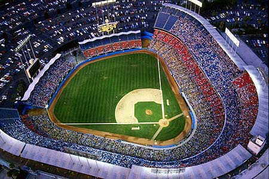

[figure not shown]

[figure not shown]

Figure 1: 56,000-seat Dodgers stadium (left), shirts and caps (middle), bobblehead (right)

```r
include_graphics(c("los_angeles-dodgers-stadium.jpg",
                 "Los-Angeles-Dodgers-Promo.jpg",
                 "adrian_bobble.jpg"))
```

The 2012 season data in the `events` table of SQLite database `data/dodgers.sqlite` contain for each of 81 home play the

- month,
- day,
- weekday,
- part of the day (day or night),
- attendance,
- opponent,
- temperature,
- whether cap or shirt or bobblehead promotions were run, and
- whether fireworks were present.

## Prerequisites

We will use `R`, `RStudio`, `R Markdown` for the next three weeks to fit statistical models to various data and analyze them. Read Wickham and Grolemund (2017) online

- [Section 1.1](https://r4ds.had.co.nz/introduction.html#prerequisites) for how to download and install `R` and `RStudio`,
- [Chapter 27](https://r4ds.had.co.nz/r-markdown.html) for how to use `R Markdown` to interact with `R` and conduct various predictive analyses.

All materials for the next three weeks will be available on [Google drive](https://drive.google.com/drive/folders/1pG135fhERGc9k2gL_DRvxt2Q05gW9KC5?usp=sharing).

## February 23: Exploratory data analysis

1. Connect to `data/dodgers.sqlite`. Read table `events` into a variable in `R`.
   - Read Baumer, Kaplan, and Horton (2017Chapters 1, 4, 5, 12) ([Second edition online](https://mdsr-book.github.io/mdsr2e/)) for getting data from and writing them to various SQL databases.
   - Because we do not want to hassle with user permissions, we will use SQLite for practice. I recommend `PostgreSQL` for real projects.
   - Open `RStudio` terminal, connect to database `dodgers.sqlite` with `sqlite3`. Explore it (there is only one table, `events`, at this time) with commands
     - `.help`
     - `.databases`
     - `.tables`
     - `.schema <table_name>`
     - `.headers on`
     - `.mode column`
     - `SELECT ...`
     - `.quit`
   - Databases are great to store and retrieve large data, especially, when they are indexed with respect to variables/columns along with we do search and match extensively.
   - `R` (likewise, `Python`) allows one to seeminglessly read from and write to databases. For fast analysis, keep data in a database, index tables for fast retrieval, use `R` or `Python` to fit models to data.

```r
library(RSQLite)
con <- dbConnect(SQLite(), "data/dodgers.sqlite")

events <- tbl(con, "events") %>%
  collect() %>%
  mutate(month = factor(month, levels = c("APR","MAY","JUN","JUL","AUG","SEP","OCT")),
         # no need to change day
         # no need to change attend
         day_of_week = factor(day_of_week, levels = c("Monday", "Tuesday", "Wednesday", "Thursday", "Friday", "Saturday", "Sunday")),
         opponent = factor(opponent, levels = c("Pirates", "Padres", "Braves", "Nationals", "Giants", "Rockies", "Snakes", "Cardinals", "Astros", "Brewers", "Angels", "White Sox", "Mets", "Reds", "Phillies", "Cubs", "Marlins")),
         temp = round((temp - 32)*5/9), # temp is converted from F to C.)
         skies = factor(skies, levels = c("Clear", "Cloudy")),
         day_night = factor(day_night, levels = c("Night", "Day")),
         cap = ifelse(cap=="YES", 1, 0),
         shirt = ifelse(shirt=="YES", 1, 0),
         fireworks = ifelse(fireworks=="YES", 1, 0),
         bobblehead = ifelse(bobblehead=="YES", 1, 0))

# events %>% distinct(month)
# events$day_of_week
# events$day_of_week %>% levels()
# events$bobblehead
```

```r
events %>%
  count(month, name = "number of games") %>%
  arrange(desc(`number of games`)) %>% # predicates coming from tidyverse package Install tidyverse using Tools menu // visit  R for Data Science Wrangling
  # show_query()  # shows the SQL command used to retrieve data from database
  collect() %>%
  pander(caption = "Number of games played in different months")
```

[output not shown]

2. What are the number of plays on each week day and in each month of a year?

   Here is the table of games aggregated according to month and day of week:

   ```r
   panderOptions("missing", "0")
   events %>%
     count(month, day_of_week, sort = TRUE) %>%
     collect() %>%
     spread(key = "day_of_week", value = "n") %>%
     #pivot_wider(names_from = "day_of_week", values_from = "n")
     pander(caption = "Number of games played in each month and on each day of week")
   ```

   Number of games played in each month and on each day of week

   | month | Monday | Tuesday | Wednesday | Thursday | Friday | Saturday | Sunday |
   | --- | --- | --- | --- | --- | --- | --- | --- |
   | APR | 1 | 2 | 2 | 1 | 2 | 2 | 2 |
   | MAY | 3 | 3 | 2 | 1 | 3 | 3 | 3 |
   | JUN | 1 | 1 | 1 | 1 | 2 | 2 | 1 |
   | JUL | 3 | 3 | 2 | 0 | 1 | 1 | 2 |
   | AUG | 2 | 2 | 3 | 1 | 3 | 2 | 2 |
   | SEP | 1 | 1 | 1 | 1 | 2 | 3 | 3 |
   | OCT | 1 | 1 | 1 | 0 | 0 | 0 | 0 |

   Alternative way of creating the same table, but more useful because we can directly run a test of independence between row and column predictors. Let us also add margins to rows and columns to see the total number of games in each month and on each day of week.

   ```r
   tbl <- xtabs(~ month + day_of_week , events)
   #chi-square test of independence
   tbl %>% addmargins() %>% pander(caption = "Same table as above, but with margins")
   ```

   Same table as above, but with margins

   |  | Monday | Tuesday | Wednesday | Thursday | Friday | Saturday | Sunday | Sum |
   | --- | --- | --- | --- | --- | --- | --- | --- | --- |
   | **APR** | 1 | 2 | 2 | 1 | 2 | 2 | 2 | 12 |
   | **MAY** | 3 | 3 | 2 | 1 | 3 | 3 | 3 | 18 |
   | **JUN** | 1 | 1 | 1 | 1 | 2 | 2 | 1 | 9 |
   | **JUL** | 3 | 3 | 2 | 0 | 1 | 1 | 2 | 12 |
   | **AUG** | 2 | 2 | 3 | 1 | 3 | 2 | 2 | 15 |
   | **SEP** | 1 | 1 | 1 | 1 | 2 | 3 | 3 | 12 |
   | **OCT** | 1 | 1 | 1 | 0 | 0 | 0 | 0 | 3 |
   | **Sum** | 12 | 13 | 12 | 5 | 13 | 13 | 13 | 81 |

   ```r
   tbl %>% summary() %>% pander ()
   ```

   Call: xtabs(formula = ~month + day_of_week, data = events) Number of cases in table: 81 Number of factors: 2

   Test for independence of all factors

   | Chisq | df | p.value |
   | --- | --- | --- |
   | 11.68 | 36 | 1 |

   Chi-squared approximation may be incorrect

   ```r
   panderOptions("missing", "-")
   ```

   Parametric chi-square test of independence is unreliable because many cells contain numbers less than five. We repeat below the test using bootstrapping (=creating many tables with replacement under independence assumption).

   ```r
   tbl %>% chisq.test(simulate.p.value = TRUE, B = 10000) %>% pander(caption = "Pearson's Chi-squared test with simulated p-value
        (based on 10000 replicates)")
   ```

   Pearson’s Chi-squared test with simulated p-value (based on 10000 replicates)

   | Test statistic | df | P value |
   | --- | --- | --- |
   | 11.68 | - | 1 |

   Pearson Chi-square test of independence has large p-value. Therefore, we cannot reject the null hypothesis, which says month and day_of_week are independent predictors if we are trying to estimate the number of games played on a day of a month.

   What happens if we are trying to predict the attendance in a game played on a day of a month?

   ```r
   panderOptions("table.split.table", Inf)
   tbl2 <- xtabs(attend ~ month + day_of_week , events)
   tbl2 %>% addmargins() %>% pander(caption = "Total attendance on all games played on a day of a month")
   ```

   Total attendance on all games played on a day of a month

   |  | Monday | Tuesday | Wednesday | Thursday | Friday | Saturday | Sunday | Sum |
   | --- | --- | --- | --- | --- | --- | --- | --- | --- |
   | **APR** | 26376 | 100014 | 56074 | 28328 | 76408 | 100791 | 87112 | 475103 |
   | **MAY** | 106041 | 131013 | 59502 | 26773 | 112780 | 109679 | 126435 | 672223 |
   | **JUN** | 50559 | 55279 | 43494 | 49006 | 90195 | 89427 | 53504 | 431464 |
   | **JUL** | 99911 | 140214 | 93525 | 0 | 43873 | 54014 | 95074 | 526611 |
   | **AUG** | 69537 | 111024 | 113853 | 54621 | 120964 | 86872 | 84402 | 641273 |
   | **SEP** | 33540 | 40619 | 50560 | 43309 | 77300 | 119165 | 102968 | 467461 |
   | **OCT** | 33624 | 42473 | 34014 | 0 | 0 | 0 | 0 | 110111 |
   | **Sum** | 419588 | 620636 | 451022 | 202037 | 521520 | 559948 | 549495 | 3324246 |

   ```r
   tbl2 %>% summary %>% pander()
   ```

   Call: xtabs(formula = attend ~ month + day_of_week, data = events) Number of cases in table: 3324246 Number of factors: 2

   Test for independence of all factors

   | Chisq | df | p.value |
   | --- | --- | --- |
   | 447277 | 36 | 0 |

   When we count the attendance on all games, p-value for the independence test turns out to be zero. Therefore, we reject the null hypothesis (= independence of month and day of week). Considering sum of attendance, we conclude the predictors month and day of week are NOT independent. We should consider adding a interaction term (product of both predictors) to regression model
3. Check the orders of the levels of the `day_of_week` and `month` factors. If necessary, put them in the logical order.

   Done in the first part.
4. How many times were bobblehead promotions run on each week day?

   ```r
   events %>%
     count(day_of_week, bobblehead) %>%
     spread(key = day_of_week, value = n) %>%
     pander(caption = "Number of games played on each day of week disaggrated according whether Bobblehead was given away or not")
   ```

   Number of games played on each day of week disaggrated according whether Bobblehead was given away or not

   | bobblehead | Monday | Tuesday | Wednesday | Thursday | Friday | Saturday | Sunday |
   | --- | --- | --- | --- | --- | --- | --- | --- |
   | 0 | 12 | 7 | 12 | 3 | 13 | 11 | 12 |
   | 1 | - | 6 | - | 2 | - | 2 | 1 |

   We cannot distinguish day and bobblehead effects on Mondays, Wednesday, Fridays.
5. How did the attendance vary across week days? Draw boxplots. On which day of week was the attendance the highest on average?

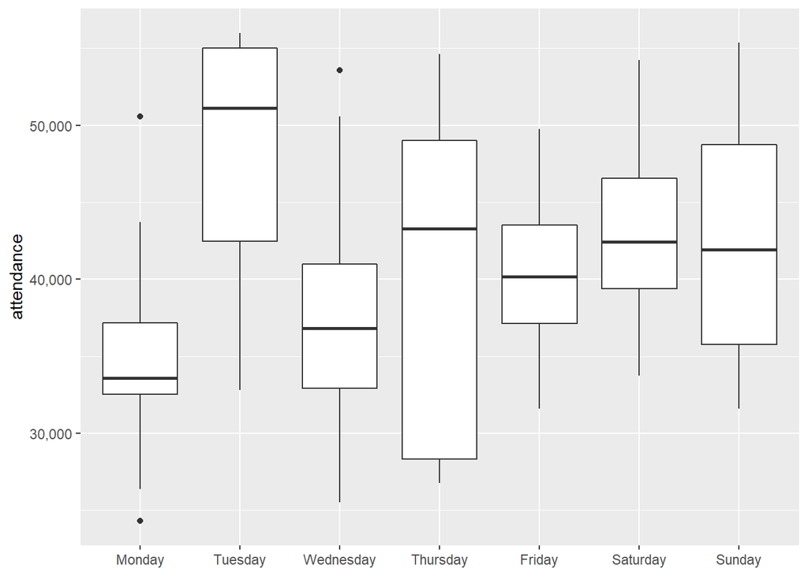

   ```r
   events %>%
     ggplot(aes(day_of_week, attend)) +
     geom_boxplot() +
     labs(x=NULL, y ="attendance") +
     scale_y_continuous(labels = scales::comma)
   ```

   - Variance of attendance changes across day of weeks.
   - On Tuesday we observed largest average (median in fact) attendance
   - Thursday variance of attendance may look large, but this is most likely because of small number of games (small sample) played on Thursday.
   - Pay attention to outliers. Try to find a reason (is it temperature, opponent, month why we have unusually large or small attendance)

   Same plot and outliers can be obtained using `Boxplot` command from `car` package.

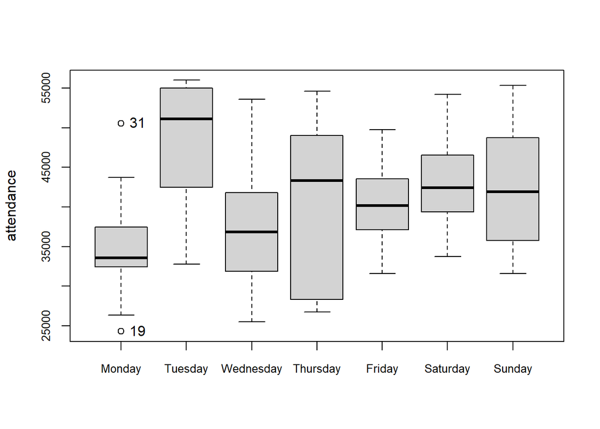

   Figure 2: Boxplot draw by car package labels the outliers with their row numbers

   ```r
   out <- Boxplot(attend ~ day_of_week, data = events, xlab = NULL, ylab = "attendance", cex.axis=.8)
   ```

   ```r
   events %>%
     mutate(row = seq(n())) %>%
     relocate(row) %>%
     slice(as.numeric(out)) %>%
     # pander(caption = "(ref:outcaption)")
     pander(caption = "Outliers appeared in the booxplots of Figure \\@ref(fig:boxcar)")
   ```

   Outliers appeared in the booxplots of Figure 2

   | row | month | day | attend | day_of_week | opponent | temp | skies | day_night | cap | shirt | fireworks | bobblehead |
   | --- | --- | --- | --- | --- | --- | --- | --- | --- | --- | --- | --- | --- |
   | 19 | MAY | 14 | 24312 | Monday | Snakes | 19 | Clear | Night | 0 | 0 | 0 | 0 |
   | 31 | JUN | 11 | 50559 | Monday | Angels | 20 | Clear | Night | 0 | 1 | 0 | 0 |

6. Is there an association between attendance and
   - whether the game is played in day light or night?
   - Between attendance and whether skies are clear or cloudy?

```r
tbl1 <- xtabs(~day_night+day_of_week, events)
tbl1 %>% addmargins() %>% pander(caption = "Number of games versus day part and day of week")
```

Number of games versus day part and day of week

|  | Monday | Tuesday | Wednesday | Thursday | Friday | Saturday | Sunday | Sum |
| --- | --- | --- | --- | --- | --- | --- | --- | --- |
| **Night** | 12 | 12 | 10 | 5 | 13 | 12 | 2 | 66 |
| **Day** | 0 | 1 | 2 | 0 | 0 | 1 | 11 | 15 |
| **Sum** | 12 | 13 | 12 | 5 | 13 | 13 | 13 | 81 |

```r
tb2 <- xtabs(attend ~ day_night + day_of_week, events)
tbl2 %>% addmargins() %>% pander(caption = "The sum of attendance across all games versus day part and day of week")
```

|  | Monday | Tuesday | Wednesday | Thursday | Friday | Saturday | Sunday | Sum |
| --- | --- | --- | --- | --- | --- | --- | --- | --- |
| **APR** | 26376 | 100014 | 56074 | 28328 | 76408 | 100791 | 87112 | 475103 |
| **MAY** | 106041 | 131013 | 59502 | 26773 | 112780 | 109679 | 126435 | 672223 |
| **JUN** | 50559 | 55279 | 43494 | 49006 | 90195 | 89427 | 53504 | 431464 |
| **JUL** | 99911 | 140214 | 93525 | 0 | 43873 | 54014 | 95074 | 526611 |
| **AUG** | 69537 | 111024 | 113853 | 54621 | 120964 | 86872 | 84402 | 641273 |
| **SEP** | 33540 | 40619 | 50560 | 43309 | 77300 | 119165 | 102968 | 467461 |
| **OCT** | 33624 | 42473 | 34014 | 0 | 0 | 0 | 0 | 110111 |
| **Sum** | 419588 | 620636 | 451022 | 202037 | 521520 | 559948 | 549495 | 3324246 |

```r
round(tb2/tbl1) %>%  pander(caption = "Average attendance for the games played during day/night on each day of week")
```

Average attendance for the games played during day/night on each day of week

|  | Monday | Tuesday | Wednesday | Thursday | Friday | Saturday | Sunday |
| --- | --- | --- | --- | --- | --- | --- | --- |
| **Night** | 34966 | 47053 | 37447 | 40407 | 40117 | 42978 | 49682 |
| **Day** | - | 56000 | 38276 | - | - | 44217 | 40921 |

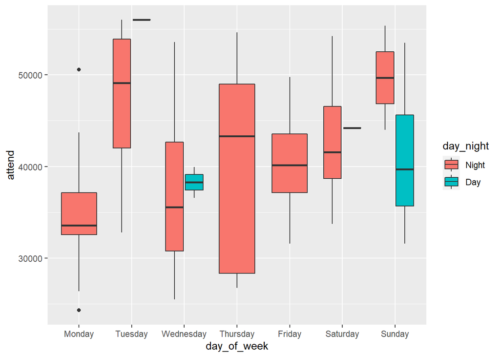

```r
events %>%
  ggplot(aes(day_of_week, attend)) +
  geom_boxplot(aes(fill=day_night))
```

The attendance seem to fluctuate widely even within night games across different day of weeks. This is am indication of interacting predictors `day_night` and `day_of_week.`

How about effect of `skies` on attendance?

```r
tbl3 <- xtabs(~ skies + month, events)
tbl3 %>% pander(caption = "Number of games played under clear/cloudy skies on each month")
```

Number of games played under clear/cloudy skies on each month

|  | APR | MAY | JUN | JUL | AUG | SEP | OCT |
| --- | --- | --- | --- | --- | --- | --- | --- |
| **Clear** | 5 | 16 | 8 | 8 | 14 | 9 | 2 |
| **Cloudy** | 7 | 2 | 1 | 4 | 1 | 3 | 1 |

```r
tbl4 <- xtabs(attend~ skies + month, events)
tbl4%>% pander(caption = "Total attendance played under clear/cloudy skies on each month")
```

Total attendance played under clear/cloudy skies on each month

|  | APR | MAY | JUN | JUL | AUG | SEP | OCT |
| --- | --- | --- | --- | --- | --- | --- | --- |
| **Clear** | 242161 | 599379 | 376185 | 356067 | 594685 | 342637 | 76097 |
| **Cloudy** | 232942 | 72844 | 55279 | 170544 | 46588 | 124824 | 34014 |

```r
round(tbl4/tbl3) %>% pander(caption = "Average attendance played under clear/cloudy skies on each month")
```

Average attendance played under clear/cloudy skies on each month

|  | APR | MAY | JUN | JUL | AUG | SEP | OCT |
| --- | --- | --- | --- | --- | --- | --- | --- |
| **Clear** | 48432 | 37461 | 47023 | 44508 | 42478 | 38071 | 38048 |
| **Cloudy** | 33277 | 36422 | 55279 | 42636 | 46588 | 41608 | 34014 |

Skies predictor seems to also have an important effect on attendance, and it also seems to interact with, for example, month variable.

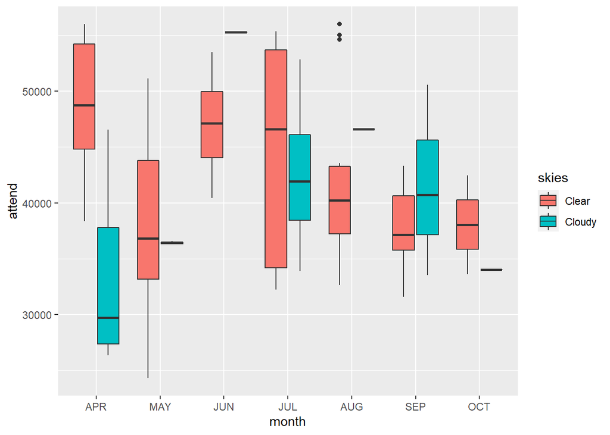

```r
events %>%
  ggplot(aes(month, attend)) +
  geom_boxplot(aes(fill=skies))
```

7. Is there an association between attendance and temperature?
   - If yes, is there a positive or negative association?
   - Do the associations differ on clear and cloud days or day or night times?

```r
events %>%
  select(attend, temp) %>%
  summary() %>%
  pander(caption = "Summary of attendance and temperature")
```

Summary of attendance and temperature

| attend | temp |
| --- | --- |
| Min. :24312 | Min. :12.00 |
| 1st Qu.:34493 | 1st Qu.:19.00 |
| Median :40284 | Median :23.00 |
| Mean :41040 | Mean :22.84 |
| 3rd Qu.:46588 | 3rd Qu.:26.00 |
| Max. :56000 | Max. :35.00 |

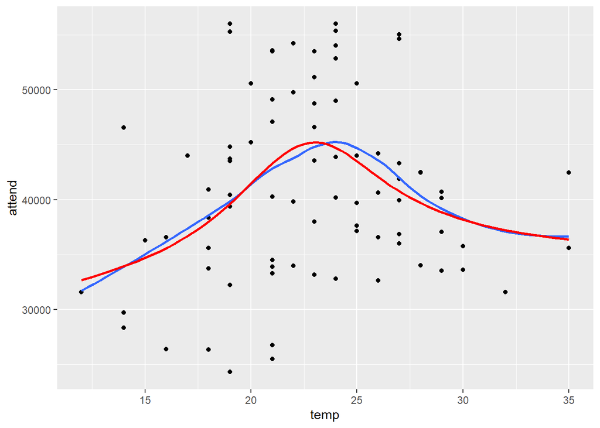

```r
events %>%
  ggplot(aes(temp, attend)) +
  #geom_jitter()
  geom_point() +
  geom_smooth(se=FALSE) +
  # geom_smooth(method = "lm", col="red", se=FALSE) +
  # geom_smooth(method = "lm", formula = y ~ poly(x, 2), col="red", lty = "dashed", se=FALSE) +
  # geom_smooth(method = "lm", formula = y ~ x + pmax(x-24, 0) + pmax(x-28, 0), col="red",se=FALSE) +
  geom_smooth(method = "lm", formula = y ~ splines::ns(x, df=4), col="red",se=FALSE)
```

## Next time: A linear regression model

Regress attendance on `month`, `day of the week`, and `bobblehead` promotion.

```r
res <- lm(attend ~ month + day_of_week + bobblehead, events)
```

```r
res
```

```
##
## Call:
## lm(formula = attend ~ month + day_of_week + bobblehead, data = events)
##
## Coefficients:
##          (Intercept)              monthMAY              monthJUN
##             33909.16              -2385.62               7163.23
##             monthJUL              monthAUG              monthSEP
##              2849.83               2377.92                 29.03
##             monthOCT    day_of_weekTuesday  day_of_weekWednesday
##              -662.67               7911.49               2460.02
##  day_of_weekThursday     day_of_weekFriday   day_of_weekSaturday
##               775.36               4883.82               6372.06
##    day_of_weekSunday            bobblehead
##              6724.00              10714.90
```

$$attendance (x) = \beta_0 + \beta_{May}^{Month} D_{May}^{Month}(x) + \beta_{Jun}^{Month} D_{Jun}^{Month}(x) + \ldots +\beta_{Oct}^{Month} D_{Oct}^{Month}(x)\\
+ \beta_{Tues}^{Week} D_{Tues}^{Week}(x) + \ldots + \beta_{Sun}^{Week} D_{Sun}^{Week}(x) + \beta_{Bobble} Bobble + \varepsilon$$
lm() already found for us the coefficients:
$$\widehat{attendance} (x) = 33909.16 -2385.62\; D_{May}^{Month}(x) + 7163.23 D_{Jun}^{Month}(x) + \ldots -662.67 D_{Oct}^{Month}(x)\\
+ 7911.49 D_{Tues}^{Week}(x) + \ldots + 6724.00^{Month} D_{Sun}^{Week}(x) + 10714.90 Bobble$$

Dummy regression variables for day of week variable:

```r
contrasts(events$day_of_week)
```

```
##           Tuesday Wednesday Thursday Friday Saturday Sunday
## Monday          0         0        0      0        0      0
## Tuesday         1         0        0      0        0      0
## Wednesday       0         1        0      0        0      0
## Thursday        0         0        1      0        0      0
## Friday          0         0        0      1        0      0
## Saturday        0         0        0      0        1      0
## Sunday          0         0        0      0        0      1
```

Dummy regression variables for month variable:

```r
contrasts(events$month)
```

```
##     MAY JUN JUL AUG SEP OCT
## APR   0   0   0   0   0   0
## MAY   1   0   0   0   0   0
## JUN   0   1   0   0   0   0
## JUL   0   0   1   0   0   0
## AUG   0   0   0   1   0   0
## SEP   0   0   0   0   1   0
## OCT   0   0   0   0   0   1
```

- How do I calculate the attendance forecast for a game to be played on a Monday in APR and no bobblehead was given away (remember Monday and Apr are reference levels for dat of week and month variables)?

  $$\text{attendance}(\text{day_of_week} = \text{Monday},\text{month} = \text{APR}, \text{bobblehead} = 0) = \beta_0 = 33909.16$$
  So $\beta_0$ is the expected attendance for a Monday game in APR when no boblehead is given away.
- How do I calculate the attendance forecast for a game to be played on a Wednesday in JUN and bobbleheads were given away (remember Monday and Apr are reference levels for dat of week and month variables)?

  $$\begin{aligned}
  \text{attendance}(\text{day_of_week} = \text{Wednesday},\text{month} = \text{JUN}, \text{bobblehead} = 1) & = \beta_0 + \beta_{Jun}^{Month} + \beta_{Wed}^{Week} + \beta_{Bobble} \\
  &= 33909.16 + 7163.23 + 2460.02 + 10714.90 \\
  &= 54247.31.
  \end{aligned}$$
  The same predictions can be calculated using R. The expected attendance for a game played on Monday in April and no bobblehead is given:

  ```r
  predict(res, newdata = tibble(month = "APR", day_of_week="Monday", bobblehead = 0)) #
  ```

  ```
  ##        1
  ## 33909.16
  ```

  The expected attendance for a game played on Wednsday in June and bobbleheads are given:

  ```r
  predict(res, newdata = data.frame(month = "JUN", day_of_week="Wednesday", bobblehead = 1), interval = "prediction", level = 0.80)
  ```

  ```
  ##        fit      lwr      upr
  ## 1 54247.32 45124.41 63370.24
  ```

   Here we want to test $H_0: \beta_{May}^{Month}=\ldots=\beta_{Oct}^{Month}=\beta_{Tues}^{Week}=\ldots=\beta_{Sun}^{Week}=\beta_{Bobble}=0$

   ```r
   small <- update(res, . ~ 1)
   anova(small, res)
   ```

   ```
   ## Analysis of Variance Table
   ##
   ## Model 1: attend ~ 1
   ## Model 2: attend ~ month + day_of_week + bobblehead
   ##   Res.Df        RSS Df  Sum of Sq      F       Pr(>F)
   ## 1     80 5507932888
   ## 2     67 2509574563 13 2998358324 6.1576 0.0000002083 ***
   ## ---
   ## Signif. codes:  0 '***' 0.001 '**' 0.01 '*' 0.05 '.' 0.1 ' ' 1
   ```

   In anova table, if small model is correct, then we expect p-value to be large (>=.05). In this case, p-value is practically zero. Therefore, we reject the small model. At least oone of the dummies will have a value different zero.
9. Does the bobblehead promotion have a statistically significant effect on the attendance?

   Here we test $H_0: \beta_{Bobble} = 0$; namely, bobblehead does not add any more attendance to game.

   ```r
   res %>% summary()
   ```

   ```
   ##
   ## Call:
   ## lm(formula = attend ~ month + day_of_week + bobblehead, data = events)
   ##
   ## Residuals:
   ##      Min       1Q   Median       3Q      Max
   ## -10786.5  -3628.1   -516.1   2230.2  14351.0
   ##
   ## Coefficients:
   ##                      Estimate Std. Error t value             Pr(>|t|)
   ## (Intercept)          33909.16    2521.81  13.446 < 0.0000000000000002 ***
   ## monthMAY             -2385.62    2291.22  -1.041              0.30152
   ## monthJUN              7163.23    2732.72   2.621              0.01083 *
   ## monthJUL              2849.83    2578.60   1.105              0.27303
   ## monthAUG              2377.92    2402.91   0.990              0.32593
   ## monthSEP                29.03    2521.25   0.012              0.99085
   ## monthOCT              -662.67    4046.45  -0.164              0.87041
   ## day_of_weekTuesday    7911.49    2702.21   2.928              0.00466 **
   ## day_of_weekWednesday  2460.02    2514.03   0.979              0.33134
   ## day_of_weekThursday    775.36    3486.15   0.222              0.82467
   ## day_of_weekFriday     4883.82    2504.65   1.950              0.05537 .
   ## day_of_weekSaturday   6372.06    2552.08   2.497              0.01500 *
   ## day_of_weekSunday     6724.00    2506.72   2.682              0.00920 **
   ## bobblehead           10714.90    2419.52   4.429            0.0000359 ***
   ## ---
   ## Signif. codes:  0 '***' 0.001 '**' 0.01 '*' 0.05 '.' 0.1 ' ' 1
   ##
   ## Residual standard error: 6120 on 67 degrees of freedom
   ## Multiple R-squared:  0.5444, Adjusted R-squared:  0.456
   ## F-statistic: 6.158 on 13 and 67 DF,  p-value: 0.0000002083
   ```

   If null hypothesis is correct (namely, small model without bobblehead term is correct), then we expect p-value (Pr(>|t|)) to be large (>0.05). Here p-value (0.0000359) is small. Therefore, we reject the null hypothesis and small model. Therefore, data suggest that bobblehead promotion will boost the ticket sales.

   Even though we concluded that bobblehead is instrumental, hypothesis testing exercise does not tell how strongly it will boost the sale. To measure the size of the effect, let us construct confidence interval for it.

   ```r
   res %>% confint(parm = "bobblehead", level = 0.80)
   ```

   ```
   ##                10 %     90 %
   ## bobblehead 7583.282 13846.53
   ```

10. Do month and day of week variables help to explain the number of attendants?

    To check whether month has an effect on attendance, test $H_0: \beta_{May}^{Month}=\ldots=\beta_{Oct}^{Month}=0$

    ```r
    small <- res %>% update(. ~ . - month)
    anova(small, res)
    ```

    ```
    ## Analysis of Variance Table
    ##
    ## Model 1: attend ~ day_of_week + bobblehead
    ## Model 2: attend ~ month + day_of_week + bobblehead
    ##   Res.Df        RSS Df Sum of Sq      F  Pr(>F)
    ## 1     73 3129721926
    ## 2     67 2509574563  6 620147363 2.7594 0.01858 *
    ## ---
    ## Signif. codes:  0 '***' 0.001 '**' 0.01 '*' 0.05 '.' 0.1 ' ' 1
    ```

    If the small model is correct (namely, month is unimportant), then we expect p-value (Pr(>F)) is large (>0.05). Because p-value value is small, I reject the small model. Therefore, month turns out to be an important variable.

    Now test if day_of_week is unimportant ($H_0: \beta_{Tues}^{Week}=\ldots=\beta_{Sun}^{Week}=0$)

    ```r
    small <- res %>% update(. ~ . - day_of_week)
    anova(small, res)
    ```

    ```
    ## Analysis of Variance Table
    ##
    ## Model 1: attend ~ month + bobblehead
    ## Model 2: attend ~ month + day_of_week + bobblehead
    ##   Res.Df        RSS Df Sum of Sq      F  Pr(>F)
    ## 1     73 3085413762
    ## 2     67 2509574563  6 575839199 2.5623 0.02704 *
    ## ---
    ## Signif. codes:  0 '***' 0.001 '**' 0.01 '*' 0.05 '.' 0.1 ' ' 1
    ```

    Since p-value is small (0.02704 < 0.05), we reject null hypothesis. Therefore, data suggest that day_of_week should be kept in the model.
11. How many fans are expected to be drawn alone by a bobblehead promotion to a home game? Give a 90% confidence interval.

    In other words, what is $\hat\beta_{bobble}$ and 90% confidence interval for $\beta_{bobble}$

    ```r
    coef(res)["bobblehead"] # exxpected attendance alone due bobblehead
    ```

    ```
    ## bobblehead
    ##    10714.9
    ```

    ```r
    confint(res, "bobblehead", level=.90)
    ```

    ```
    ##                 5 %     95 %
    ## bobblehead 6679.347 14750.46
    ```

12. How good does the model fit to the data? Why? Comment on residual standard error and R$^2$. Plot observed attendance against predicted attendance.
    - R2 = coefficient of determination = percentage of variation in attendance explained by the model. Always it is between 0, 1. A model that has large R2 is a good model.
    - RSE = estimate of error standard deviation. It measures the size of forecast error. The smaller the better. Typically we compare RSE against the median of response (attendance).

    Error percentage

    ```r
    100*sigma(res)/median(events$attend) # percent error
    ```

    ```
    ## [1] 15.19253
    ```

    R2

    ```r
    summary(res)$r.square
    ```

    ```
    ## [1] 0.5443709
    ```

    Our model can explain 54% of variation in attendance.

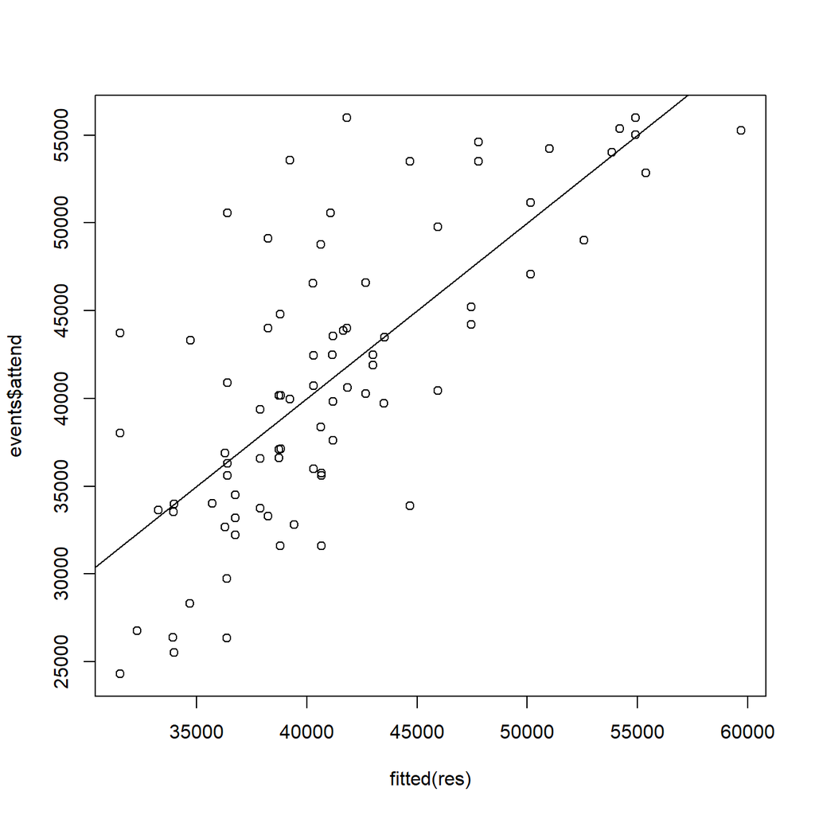

    ```r
    plot(fitted(res), events$attend)
    abline(0, 1)
    ```

13. Predict the number of attendees to a typical home game on a Wednesday in June if a bobblehead promotion is extended. Give a 90% prediction interval.

    ```r
    # predict(res, newdata = data.frame(day_of_week="Wednesday", month = "JUN", bobblehead=1), se.fit = TRUE)
    predict(res, newdata = data.frame(day_of_week="Wednesday", month = "JUN", bobblehead=1), interval = "predict", level= 0.90)
    ```

    ```
    ##        fit     lwr      upr
    ## 1 54247.32 42491.1 66003.55
    ```

# Model selection

We can compare nested models using anova (F-test). Even if models are nested, anova test does not give the model with the superior generalization power (power to learn the most from the training set to apply on the unseen data in the future). We need to estimate the real predictive power of a model. Better candidates

- information criteria (AIC, BIC, AICc, MLD)
- cross-validation

What is AIC?
$$AIC = - 2 \text{ log likelihood} + 2 \text{ number of parameters} \\
BIC = - 2 \text{ log likelihood} +\log (\text{sample size}) \times \text{ number of parameters} \\$$

```r
complex <- res %>%
  update(. ~ .^2)

AIC(res, complex)
```

```
##         df      AIC
## res     15 1657.031
## complex 49 1654.403
```

```r
BIC(res, complex)
```

```
##         df      BIC
## res     15 1692.948
## complex 49 1771.731
```

```r
res %>% coef() %>% length()
```

```
## [1] 14
```

```r
complex %>% coef %>% na.omit %>% length()
```

```
## [1] 48
```

```r
res %>%
  step(direction = "forward", scope = list(lower = res,  upper = update(res, . ~ .^2)))
```

```
## Start:  AIC=1425.16
## attend ~ month + day_of_week + bobblehead
##
##                          Df  Sum of Sq        RSS    AIC
## + month:day_of_week      31 1426678647 1082895916 1419.1
## <none>                                 2509574563 1425.2
## + day_of_week:bobblehead  3   40475650 2469098913 1429.8
## + month:bobblehead        4   84850093 2424724470 1430.4
##
## Step:  AIC=1419.08
## attend ~ month + day_of_week + bobblehead + month:day_of_week
##
##                          Df Sum of Sq        RSS    AIC
## <none>                                1082895916 1419.1
## + month:bobblehead        2  21481210 1061414706 1421.5
## + day_of_week:bobblehead  2  16441821 1066454095 1421.8
```

```
##
## Call:
## lm(formula = attend ~ month + day_of_week + bobblehead + month:day_of_week,
##     data = events)
##
## Coefficients:
##                   (Intercept)                       monthMAY
##                         26376                           8971
##                      monthJUN                       monthJUL
##                         24183                           6928
##                      monthAUG                       monthSEP
##                          8393                           7164
##                      monthOCT             day_of_weekTuesday
##                          7248                          23631
##          day_of_weekWednesday            day_of_weekThursday
##                          1661                           1952
##             day_of_weekFriday            day_of_weekSaturday
##                         11828                          17884
##             day_of_weekSunday                     bobblehead
##                         17180                          12272
##   monthMAY:day_of_weekTuesday    monthJUN:day_of_weekTuesday
##                        -23488                         -31183
##   monthJUL:day_of_weekTuesday    monthAUG:day_of_weekTuesday
##                        -14287                         -15159
##   monthSEP:day_of_weekTuesday    monthOCT:day_of_weekTuesday
##                        -16552                         -14782
## monthMAY:day_of_weekWednesday  monthJUN:day_of_weekWednesday
##                         -7257                          -8726
## monthJUL:day_of_weekWednesday  monthAUG:day_of_weekWednesday
##                         11798                           1521
## monthSEP:day_of_weekWednesday  monthOCT:day_of_weekWednesday
##                         15359                          -1271
##  monthMAY:day_of_weekThursday   monthJUN:day_of_weekThursday
##                        -10526                         -15777
##  monthJUL:day_of_weekThursday   monthAUG:day_of_weekThursday
##                            NA                           5629
##  monthSEP:day_of_weekThursday   monthOCT:day_of_weekThursday
##                          7817                             NA
##    monthMAY:day_of_weekFriday     monthJUN:day_of_weekFriday
##                         -9582                         -17289
##    monthJUL:day_of_weekFriday     monthAUG:day_of_weekFriday
##                         -1259                          -6275
##    monthSEP:day_of_weekFriday     monthOCT:day_of_weekFriday
##                         -6718                             NA
##  monthMAY:day_of_weekSaturday   monthJUN:day_of_weekSaturday
##                        -16671                         -23729
##  monthJUL:day_of_weekSaturday   monthAUG:day_of_weekSaturday
##                         -9445                          -9216
##  monthSEP:day_of_weekSaturday   monthOCT:day_of_weekSaturday
##                        -11702                             NA
##    monthMAY:day_of_weekSunday     monthJUN:day_of_weekSunday
##                        -10382                         -14235
##    monthJUL:day_of_weekSunday     monthAUG:day_of_weekSunday
##                         -9083                          -9747
##    monthSEP:day_of_weekSunday     monthOCT:day_of_weekSunday
##                        -16397                             NA
```

```r
complex %>% step(direction = "backward")
```

```
## Start:  AIC=1422.53
## attend ~ month + day_of_week + bobblehead + month:day_of_week +
##     month:bobblehead + day_of_week:bobblehead
##
##                          Df  Sum of Sq        RSS    AIC
## - day_of_week:bobblehead  1   12082574 1061414706 1421.5
## - month:bobblehead        1   17121963 1066454095 1421.8
## <none>                                 1049332132 1422.5
## - month:day_of_week      27 1335988226 2385320358 1435.0
##
## Step:  AIC=1421.46
## attend ~ month + day_of_week + bobblehead + month:day_of_week +
##     month:bobblehead
##
##                     Df  Sum of Sq        RSS    AIC
## - month:bobblehead   2   21481210 1082895916 1419.1
## <none>                            1061414706 1421.5
## - month:day_of_week 29 1363309764 2424724470 1430.4
##
## Step:  AIC=1419.08
## attend ~ month + day_of_week + bobblehead + month:day_of_week
##
##                     Df  Sum of Sq        RSS    AIC
## <none>                            1082895916 1419.1
## - month:day_of_week 31 1426678647 2509574563 1425.2
## - bobblehead         1  351400539 1434296455 1439.8
```

```
##
## Call:
## lm(formula = attend ~ month + day_of_week + bobblehead + month:day_of_week,
##     data = events)
##
## Coefficients:
##                   (Intercept)                       monthMAY
##                         26376                           8971
##                      monthJUN                       monthJUL
##                         24183                           6928
##                      monthAUG                       monthSEP
##                          8393                           7164
##                      monthOCT             day_of_weekTuesday
##                          7248                          23631
##          day_of_weekWednesday            day_of_weekThursday
##                          1661                           1952
##             day_of_weekFriday            day_of_weekSaturday
##                         11828                          17884
##             day_of_weekSunday                     bobblehead
##                         17180                          12272
##   monthMAY:day_of_weekTuesday    monthJUN:day_of_weekTuesday
##                        -23488                         -31183
##   monthJUL:day_of_weekTuesday    monthAUG:day_of_weekTuesday
##                        -14287                         -15159
##   monthSEP:day_of_weekTuesday    monthOCT:day_of_weekTuesday
##                        -16552                         -14782
## monthMAY:day_of_weekWednesday  monthJUN:day_of_weekWednesday
##                         -7257                          -8726
## monthJUL:day_of_weekWednesday  monthAUG:day_of_weekWednesday
##                         11798                           1521
## monthSEP:day_of_weekWednesday  monthOCT:day_of_weekWednesday
##                         15359                          -1271
##  monthMAY:day_of_weekThursday   monthJUN:day_of_weekThursday
##                        -10526                         -15777
##  monthJUL:day_of_weekThursday   monthAUG:day_of_weekThursday
##                            NA                           5629
##  monthSEP:day_of_weekThursday   monthOCT:day_of_weekThursday
##                          7817                             NA
##    monthMAY:day_of_weekFriday     monthJUN:day_of_weekFriday
##                         -9582                         -17289
##    monthJUL:day_of_weekFriday     monthAUG:day_of_weekFriday
##                         -1259                          -6275
##    monthSEP:day_of_weekFriday     monthOCT:day_of_weekFriday
##                         -6718                             NA
##  monthMAY:day_of_weekSaturday   monthJUN:day_of_weekSaturday
##                        -16671                         -23729
##  monthJUL:day_of_weekSaturday   monthAUG:day_of_weekSaturday
##                         -9445                          -9216
##  monthSEP:day_of_weekSaturday   monthOCT:day_of_weekSaturday
##                        -11702                             NA
##    monthMAY:day_of_weekSunday     monthJUN:day_of_weekSunday
##                        -10382                         -14235
##    monthJUL:day_of_weekSunday     monthAUG:day_of_weekSunday
##                         -9083                          -9747
##    monthSEP:day_of_weekSunday     monthOCT:day_of_weekSunday
##                        -16397                             NA
```

```r
complex %>% step(direction = "both")
```

```
## Start:  AIC=1422.53
## attend ~ month + day_of_week + bobblehead + month:day_of_week +
##     month:bobblehead + day_of_week:bobblehead
##
##                          Df  Sum of Sq        RSS    AIC
## - day_of_week:bobblehead  1   12082574 1061414706 1421.5
## - month:bobblehead        1   17121963 1066454095 1421.8
## <none>                                 1049332132 1422.5
## - month:day_of_week      27 1335988226 2385320358 1435.0
##
## Step:  AIC=1421.46
## attend ~ month + day_of_week + bobblehead + month:day_of_week +
##     month:bobblehead
##
##                          Df  Sum of Sq        RSS    AIC
## - month:bobblehead        2   21481210 1082895916 1419.1
## <none>                                 1061414706 1421.5
## + day_of_week:bobblehead  1   12082574 1049332132 1422.5
## - month:day_of_week      29 1363309764 2424724470 1430.4
##
## Step:  AIC=1419.08
## attend ~ month + day_of_week + bobblehead + month:day_of_week
##
##                          Df  Sum of Sq        RSS    AIC
## <none>                                 1082895916 1419.1
## + month:bobblehead        2   21481210 1061414706 1421.5
## + day_of_week:bobblehead  2   16441821 1066454095 1421.8
## - month:day_of_week      31 1426678647 2509574563 1425.2
## - bobblehead              1  351400539 1434296455 1439.8
```

```
##
## Call:
## lm(formula = attend ~ month + day_of_week + bobblehead + month:day_of_week,
##     data = events)
##
## Coefficients:
##                   (Intercept)                       monthMAY
##                         26376                           8971
##                      monthJUN                       monthJUL
##                         24183                           6928
##                      monthAUG                       monthSEP
##                          8393                           7164
##                      monthOCT             day_of_weekTuesday
##                          7248                          23631
##          day_of_weekWednesday            day_of_weekThursday
##                          1661                           1952
##             day_of_weekFriday            day_of_weekSaturday
##                         11828                          17884
##             day_of_weekSunday                     bobblehead
##                         17180                          12272
##   monthMAY:day_of_weekTuesday    monthJUN:day_of_weekTuesday
##                        -23488                         -31183
##   monthJUL:day_of_weekTuesday    monthAUG:day_of_weekTuesday
##                        -14287                         -15159
##   monthSEP:day_of_weekTuesday    monthOCT:day_of_weekTuesday
##                        -16552                         -14782
## monthMAY:day_of_weekWednesday  monthJUN:day_of_weekWednesday
##                         -7257                          -8726
## monthJUL:day_of_weekWednesday  monthAUG:day_of_weekWednesday
##                         11798                           1521
## monthSEP:day_of_weekWednesday  monthOCT:day_of_weekWednesday
##                         15359                          -1271
##  monthMAY:day_of_weekThursday   monthJUN:day_of_weekThursday
##                        -10526                         -15777
##  monthJUL:day_of_weekThursday   monthAUG:day_of_weekThursday
##                            NA                           5629
##  monthSEP:day_of_weekThursday   monthOCT:day_of_weekThursday
##                          7817                             NA
##    monthMAY:day_of_weekFriday     monthJUN:day_of_weekFriday
##                         -9582                         -17289
##    monthJUL:day_of_weekFriday     monthAUG:day_of_weekFriday
##                         -1259                          -6275
##    monthSEP:day_of_weekFriday     monthOCT:day_of_weekFriday
##                         -6718                             NA
##  monthMAY:day_of_weekSaturday   monthJUN:day_of_weekSaturday
##                        -16671                         -23729
##  monthJUL:day_of_weekSaturday   monthAUG:day_of_weekSaturday
##                         -9445                          -9216
##  monthSEP:day_of_weekSaturday   monthOCT:day_of_weekSaturday
##                        -11702                             NA
##    monthMAY:day_of_weekSunday     monthJUN:day_of_weekSunday
##                        -10382                         -14235
##    monthJUL:day_of_weekSunday     monthAUG:day_of_weekSunday
##                         -9083                          -9747
##    monthSEP:day_of_weekSunday     monthOCT:day_of_weekSunday
##                        -16397                             NA
```

```r
res_bic <- complex %>% step(direction = "both", k = log(nrow(events)))  #  use BIC rather han AIC
```

```
## Start:  AIC=1537.47
## attend ~ month + day_of_week + bobblehead + month:day_of_week +
##     month:bobblehead + day_of_week:bobblehead
##
##                          Df  Sum of Sq        RSS    AIC
## - month:day_of_week      27 1335988226 2385320358 1485.3
## - day_of_week:bobblehead  1   12082574 1061414706 1534.0
## - month:bobblehead        1   17121963 1066454095 1534.4
## <none>                                 1049332132 1537.5
##
## Step:  AIC=1485.33
## attend ~ month + day_of_week + bobblehead + month:bobblehead +
##     day_of_week:bobblehead
##
##                          Df  Sum of Sq        RSS    AIC
## - month:bobblehead        4   83778555 2469098913 1470.5
## - day_of_week:bobblehead  3   39404112 2424724470 1473.5
## <none>                                 2385320358 1485.3
## + month:day_of_week      27 1335988226 1049332132 1537.5
##
## Step:  AIC=1470.55
## attend ~ month + day_of_week + bobblehead + day_of_week:bobblehead
##
##                          Df  Sum of Sq        RSS    AIC
## - day_of_week:bobblehead  3   40475650 2509574563 1458.7
## - month                   6  578880329 3047979242 1461.2
## <none>                                 2469098913 1470.5
## + month:bobblehead        4   83778555 2385320358 1485.3
## + month:day_of_week      30 1402644818 1066454095 1534.4
##
## Step:  AIC=1458.69
## attend ~ month + day_of_week + bobblehead
##
##                          Df  Sum of Sq        RSS    AIC
## - day_of_week             6  575839199 3085413762 1449.0
## - month                   6  620147363 3129721926 1450.2
## <none>                                 2509574563 1458.7
## + day_of_week:bobblehead  3   40475650 2469098913 1470.5
## + month:bobblehead        4   84850093 2424724470 1473.5
## - bobblehead              1  734587177 3244161740 1475.1
## + month:day_of_week      31 1426678647 1082895916 1526.8
##
## Step:  AIC=1449.05
## attend ~ month + bobblehead
##
##                    Df  Sum of Sq        RSS    AIC
## - month             6  557523389 3642937151 1436.1
## <none>                           3085413762 1449.0
## + day_of_week       6  575839199 2509574563 1458.7
## + month:bobblehead  4  114596644 2970817117 1463.6
## - bobblehead        1 1473561009 4558974770 1476.3
##
## Step:  AIC=1436.14
## attend ~ bobblehead
##
##               Df  Sum of Sq        RSS    AIC
## <none>                      3642937151 1436.1
## + month        6  557523389 3085413762 1449.0
## + day_of_week  6  513215226 3129721926 1450.2
## - bobblehead   1 1864995736 5507932888 1465.2
```

Because we have small sample, BIC may return underfitted models, so use AIC. Or even better use cross-validation.

```r
nfold <-  4
set.seed(1)
id_fold <- rep(1:4, len = nrow(events)) %>% sample()
events
```

```
## # A tibble: 81 x 12
##    month   day attend day_of_week opponent   temp skies  day_night   cap shirt
##    <fct> <dbl>  <dbl> <fct>       <fct>     <dbl> <fct>  <fct>     <dbl> <dbl>
##  1 APR      10  56000 Tuesday     Pirates      19 Clear  Day           0     0
##  2 APR      11  29729 Wednesday   Pirates      14 Cloudy Night         0     0
##  3 APR      12  28328 Thursday    Pirates      14 Cloudy Night         0     0
##  4 APR      13  31601 Friday      Padres       12 Cloudy Night         0     0
##  5 APR      14  46549 Saturday    Padres       14 Cloudy Night         0     0
##  6 APR      15  38359 Sunday      Padres       18 Clear  Day           0     0
##  7 APR      23  26376 Monday      Braves       16 Cloudy Night         0     0
##  8 APR      24  44014 Tuesday     Braves       17 Cloudy Night         0     0
##  9 APR      25  26345 Wednesday   Braves       18 Cloudy Night         0     0
## 10 APR      27  44807 Friday      Nationals    19 Clear  Night         0     0
## # ... with 71 more rows, and 2 more variables: fireworks <dbl>,
## #   bobblehead <dbl>
```

```r
rmse_res <- rep(NA, nfold)
rmse_bic <- rep(NA, nfold)
for (i in seq(nfold)){
  test <- events[id_fold == i,]
  train <- events[id_fold != i,]

  lmod <- update(res, data = train)
  pred_test <- predict(lmod, newdata= test)
  rmse_res[i] <- sqrt(mean((test$attend - pred_test)^2))

  lmod_bic <- update(res_bic, data = train)
  pred_test_bic <- predict(lmod_bic, newdata= test)
  rmse_bic[i] <- sqrt(mean((test$attend - pred_test_bic)^2))
}

rmse_res %>% mean()
```

```
## [1] 6404.04
```

```r
rmse_bic %>% mean()
```

```
## [1] 6691.248
```

```r
full_reg = res <- lm(attend ~ month + day + day_of_week + opponent + temp + skies + bobblehead + day, events)
full_reg
```

```
##
## Call:
## lm(formula = attend ~ month + day + day_of_week + opponent +
##     temp + skies + bobblehead + day, data = events)
##
## Coefficients:
##          (Intercept)              monthMAY              monthJUN
##             33425.40               2813.79               -983.15
##             monthJUL              monthAUG              monthSEP
##              3204.27               6034.39               2622.31
##             monthOCT                   day    day_of_weekTuesday
##              4472.38                142.19               8386.42
## day_of_weekWednesday   day_of_weekThursday     day_of_weekFriday
##              2659.00                491.38               2333.28
##  day_of_weekSaturday     day_of_weekSunday        opponentPadres
##              4330.72               3316.35                954.32
##       opponentBraves     opponentNationals        opponentGiants
##             -6759.80               4299.24              -5684.48
##      opponentRockies        opponentSnakes     opponentCardinals
##             -5311.92              -7953.74              -1704.07
##       opponentAstros       opponentBrewers        opponentAngels
##             -7138.12             -11403.70               8560.54
##    opponentWhite Sox          opponentMets          opponentReds
##              7413.09               4357.19               -270.16
##     opponentPhillies          opponentCubs       opponentMarlins
##             -1072.53                506.14              -6720.17
##                 temp           skiesCloudy            bobblehead
##                44.75              -2275.75               9839.67
```

## Project (will be graded)

- can be done in groups of three at most
- due 19:00 March 20, Saturday
- submit to Moodle course page zipped Rmd, html files

Include **all variables** and conduct a full regression analysis of the problem. Submit your `R markdown` and `html` files to course homepage on moodle.

## Bibliography

Baumer, B. S., D. T. Kaplan, and N. J. Horton. 2017. *Modern Data Science with R*. Chapman & Hall/CRC Texts in Statistical Science. CRC Press. https://books.google.com.tr/books?id=NrddDgAAQBAJ.

Miller, T. W. 2014. *Modeling Techniques in Predictive Analytics with Python and R: A Guide to Data Science*. FT Press Analytics. Pearson Education. https://books.google.com.tr/books?id=PU6nBAAAQBAJ.

Wickham, H., and G. Grolemund. 2017. *R for Data Science*. O’Reilly Media. https://books.google.com.tr/books?id=aZRYrgEACAAJ.